# Problem 4

#### Installing libraries

```r
install.packages("QuantPsyc")
install.packages("gmodels")
install.packages("moments")
install.packages("olsrr")
library('dplyr')
library("QuantPsyc")
library("gmodels")
library("moments")
library (MASS)
library (dplyr)
library(shiny)
library(tidyverse)
library("olsrr")
library("nlme")
```

#### Reading data

```r
data <- read_tsv('data/telco.txt') %>% dplyr::select(-index)
```

#### Item 1

To include ed into the model dummy variables should be used. We have a clear order in variable but we can’t define the intervals and the intervals are not equal for sure. If we will add them as numerical column they will inherit unnecessary releationships and operations.

```r
unique(data$ed)
```

```
[1] "College degree"               "Post-undergraduate degree"    "Did not complete high school"
[4] "High school degree"           "Some college"
```

#### Item 2

We can see that target variable highly skewed. We can also measure it and double check.

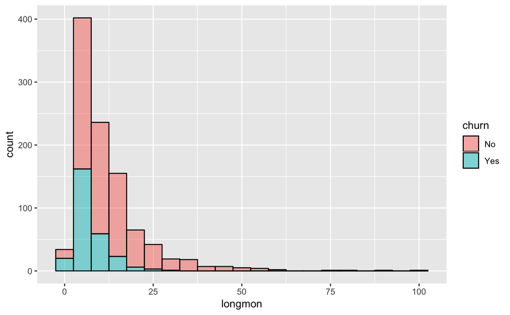

```r
ggplot(data) + geom_histogram(aes(x=longmon, fill=churn), color="black", alpha=0.5, binwidth=5)
```

```r
skewness(data$longmon)
```

```
[1] 2.961653
```

Taking log of target variable makes it much more normalized(skewness is almost 0)

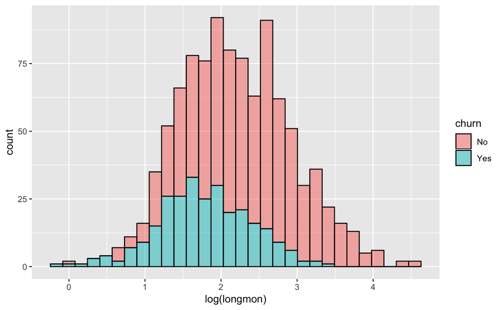

```r
ggplot(data) + geom_histogram(aes(x=log(longmon), fill=churn), color="black", alpha=0.5)
```

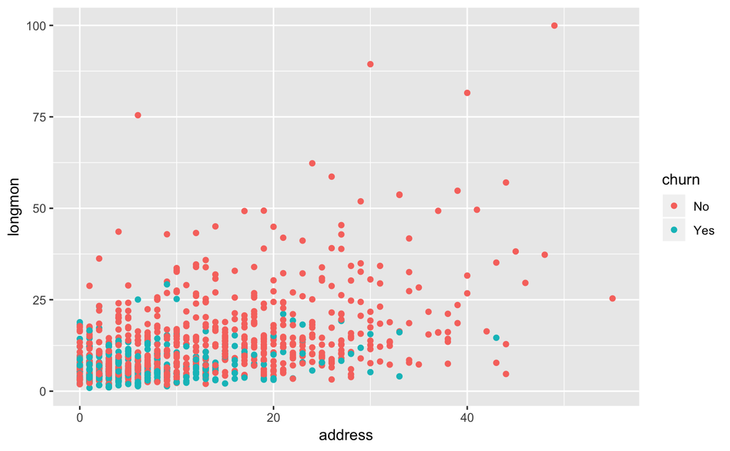

```r
ggplot(data) + geom_point(aes(x=address, y=longmon, color=churn))
```

Wiremon clearly have two subsets - 0 and not 0. The idea is to watch at statistics for each of these groups and inspect deeper. Possibly they have some hidden pattern why the data is splitted in this way

```
Ignoring unknown parameters: bins
```

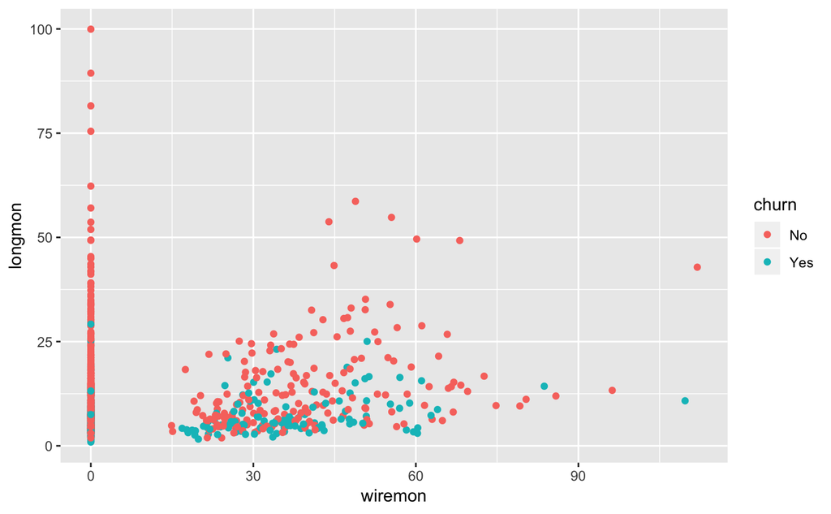

```r
ggplot(data) + geom_point(aes(x=wiremon, y=longmon, color=churn), bins=30)
```

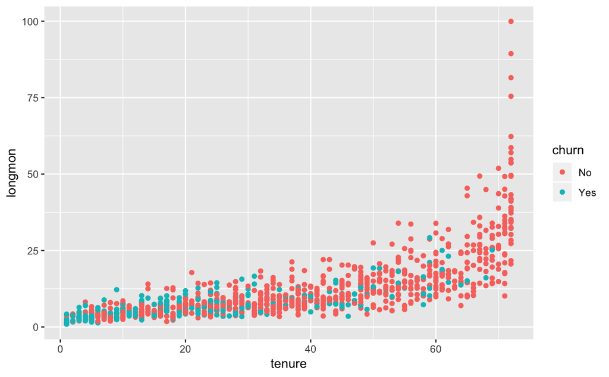

```r
ggplot(data) + geom_point(aes(x=tenure, y=longmon, color=churn))
```

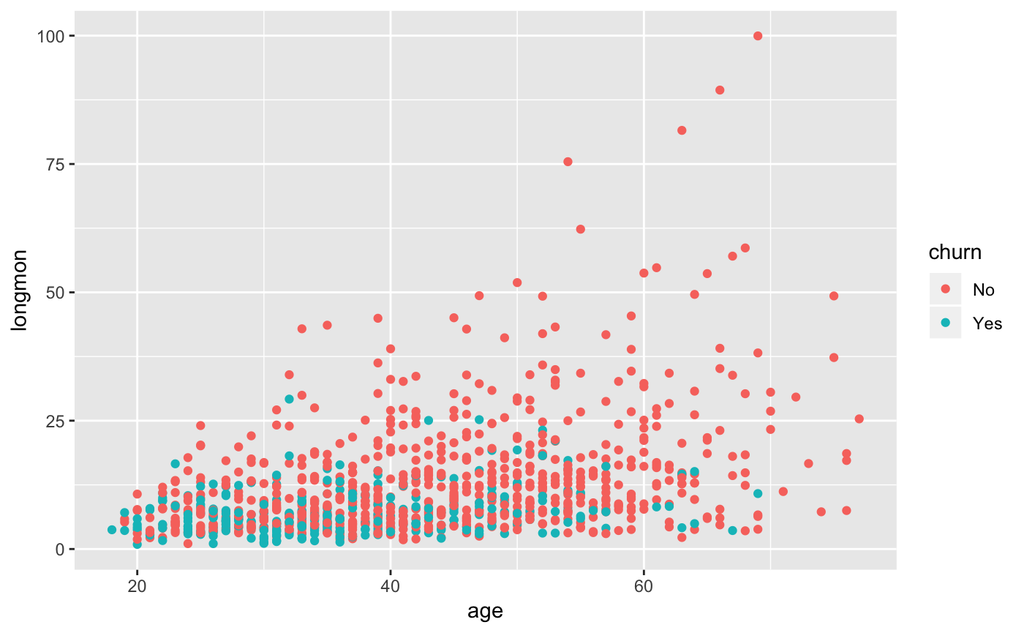

```r
ggplot(data) + geom_point(aes(x=age, y=longmon, color=churn))
```

Income has outliers that are far away from the majority of the data. Taking log of this variable is a good way to normalize the distribution and move outliers closer to the majority of the data

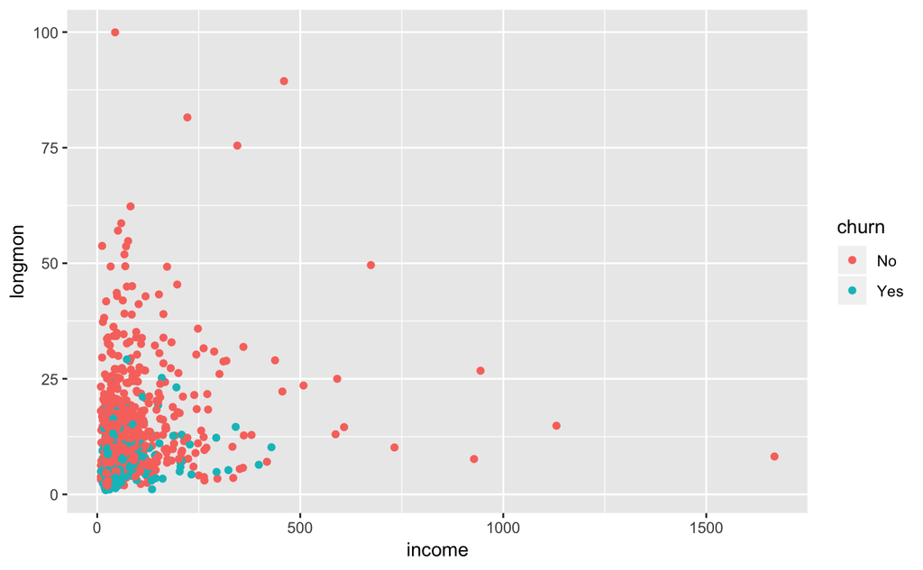

```r
ggplot(data) + geom_point(aes(x=income, y=longmon, color=churn))
```

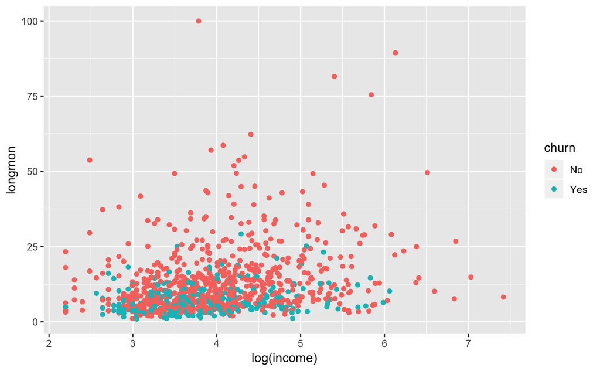

```r
ggplot(data) + geom_point(aes(x=log(income), y=longmon, color=churn))
```

#### Item 3

```r
data <- read_tsv('data/telco.txt') %>% dplyr::select(-index)
```

```r
data <- data %>% mutate(longmon=log(longmon),
                income=log(income))
```

```r
fit <- lm(longmon ~ ., data=data)
```

Summary of fitted linear model. We can see that some ed values are seems to be insignificant, and some are significant. We can run GLH test to check simultaneous significance of the ed variable

```r
summary(fit)
```

```
Call:
lm(formula = longmon ~ ., data = data)

Residuals:
     Min       1Q   Median       3Q      Max
-1.25575 -0.24777  0.00182  0.25315  1.22081

Coefficients:
                                 Estimate Std. Error t value Pr(>|t|)
(Intercept)                     1.2452281  0.1072704  11.608  < 2e-16 ***
tenure                          0.0272908  0.0007843  34.798  < 2e-16 ***
age                            -0.0027688  0.0016712  -1.657  0.09789 .
maritalUnmarried               -0.0721008  0.0255870  -2.818  0.00493 **
address                         0.0037513  0.0017356   2.161  0.03091 *
income                          0.0214335  0.0265511   0.807  0.41971
edDid not complete high school -0.1155081  0.0432154  -2.673  0.00765 **
edHigh school degree           -0.0239285  0.0369398  -0.648  0.51728
edPost-undergraduate degree    -0.1059205  0.0552153  -1.918  0.05536 .
edSome college                 -0.0354957  0.0383243  -0.926  0.35457
employ                          0.0017811  0.0023620   0.754  0.45099
retireYes                       0.2457388  0.0794830   3.092  0.00205 **
genderMale                      0.0356641  0.0250931   1.421  0.15555
wiremon                        -0.0001376  0.0006812  -0.202  0.83996
churnYes                       -0.0397296  0.0308736  -1.287  0.19845
---
Signif. codes:  0 '***' 0.001 '**' 0.01 '*' 0.05 '.' 0.1 ' ' 1

Residual standard error: 0.3933 on 985 degrees of freedom
Multiple R-squared:  0.7173,    Adjusted R-squared:  0.7133
F-statistic: 178.5 on 14 and 985 DF,  p-value: < 2.2e-16
```

```r
R <- rbind(c(0, 0, 0, 0, 0, 0, 1, 0, 0, 0, 0, 0, 0, 0 ,0), c(0, 0, 0, 0, 0, 0, 0, 1, 0, 0, 0, 0, 0, 0 ,0),
           c(0, 0, 0, 0, 0, 0, 0, 0, 1, 0, 0, 0, 0, 0 ,0), c(0, 0, 0, 0, 0, 0, 0, 0, 0, 1, 0, 0, 0, 0 ,0))
r <- c(0, 0, 0, 0)
```

```r
glh.test(fit, R, r)
```

```
     Test of General Linear Hypothesis
Call:
glh.test(reg = fit, cm = R, d = r)
F = 2.7504, df1 =   4, df2 = 985, p-value = 0.02711
```

#### Item 4

We haven’t applied any transformations to the address, ed or retire but we did log for target variable. Address - if we change address by 1 , we’d expect our target variable longmon to change by 100 x $\beta_{address}$ percent

Ed - if education level specified , we’d expect our target variable longmon to be bigger/lower by 100 x $\beta_{ed}$ percent. We need to keep in mind that one of the catregories is in intercept term so our baseline is not **no education** but rather **education level that is in intercept term**

Retire - if retire , we’d expect our target variable longmon to be bigger/lower by 100 * $\beta_{retire}$ percent than having non retire

#### Item 5

Let’s test the residuals are drawn from normal distribution

High p-value indicates weak evidence against H0(samples are from the same distribution)

```r
ks.test(fit$residuals, "pnorm", mean=mean(fit$residuals), sd = sqrt(var(fit$residuals)))
```

```
    One-sample Kolmogorov-Smirnov test

data:  fit$residuals
D = 0.019865, p-value = 0.8249
alternative hypothesis: two-sided
```

Computin confidence intervals

We’re 95% confident that the interval captured the true parameter value of our data.

Whenever an effect is significant, all values in the confidence interval will be on the same side of zero

We can see that 0 included for income parameter and that means it is not significant.

Address is significant

```r
confint(fit, c("address", "income"))
```

```
                2.5 %      97.5 %
address  0.0003453452 0.007157228
income  -0.0306697034 0.073536763
```

#### Item 6

I am using default R’s step optimization with backward optimization. Selection is performed using AIC. Removes the least important (by p-value) predictors and iteratively tries to find the best AIC model with least number of features. For R, model has provide add, drop and extractAIC method to be optimized with step function.

```r
step(lm(longmon ~ .,data=data), direction='backward')
```

```
Start:  AIC=-1851.35
longmon ~ tenure + age + marital + address + income + ed + employ +
    retire + gender + wiremon + churn

          Df Sum of Sq    RSS     AIC
- wiremon  1     0.006 152.39 -1853.3
- employ   1     0.088 152.47 -1852.8
- income   1     0.101 152.49 -1852.7
- churn    1     0.256 152.64 -1851.7
<none>                 152.38 -1851.3
- gender   1     0.313 152.70 -1851.3
- age      1     0.425 152.81 -1850.6
- address  1     0.723 153.11 -1848.6
- ed       4     1.702 154.09 -1848.2
- marital  1     1.228 153.61 -1845.3
- retire   1     1.479 153.86 -1843.7
- tenure   1   187.332 339.72 -1051.6

Step:  AIC=-1853.31
longmon ~ tenure + age + marital + address + income + ed + employ +
    retire + gender + churn

          Df Sum of Sq    RSS     AIC
- employ   1     0.089 152.48 -1854.7
- income   1     0.097 152.49 -1854.7
- churn    1     0.267 152.66 -1853.6
<none>                 152.39 -1853.3
- gender   1     0.313 152.70 -1853.3
- age      1     0.426 152.82 -1852.5
- address  1     0.728 153.12 -1850.5
- ed       4     1.702 154.09 -1850.2
- marital  1     1.224 153.61 -1847.3
- retire   1     1.475 153.87 -1845.7
- tenure   1   189.740 342.13 -1046.6

Step:  AIC=-1854.72
longmon ~ tenure + age + marital + address + income + ed + retire +
    gender + churn

          Df Sum of Sq    RSS     AIC
```

[output cut: 24 more lines]

```
- tenure   1   220.700 373.46  -962.93

Call:
lm(formula = longmon ~ tenure + age + marital + address + income +
    ed + retire + gender, data = data)

Coefficients:
                   (Intercept)                          tenure                             age
                      1.160551                        0.027677                       -0.002325
              maritalUnmarried                         address                          income
                     -0.071715                        0.003718                        0.033964
edDid not complete high school            edHigh school degree     edPost-undergraduate degree
                     -0.095663                       -0.010947                       -0.112466
                edSome college                       retireYes                      genderMale
                     -0.026560                        0.266762                        0.035561
```

##### Best model

```r
fit <- lm(formula = longmon ~ tenure + age + marital + address + income +
    ed + retire + gender, data = data)
```

```r
summary(fit)
```

```
Call:
lm(formula = longmon ~ tenure + age + marital + address + income +
    ed + retire + gender, data = data)

Residuals:
    Min      1Q  Median      3Q     Max
-1.2715 -0.2447  0.0058  0.2499  1.2452

Coefficients:
                                 Estimate Std. Error t value Pr(>|t|)
(Intercept)                     1.1605511  0.0753358  15.405  < 2e-16 ***
tenure                          0.0276773  0.0007326  37.781  < 2e-16 ***
age                            -0.0023251  0.0016040  -1.450 0.147485
maritalUnmarried               -0.0717149  0.0255619  -2.806 0.005122 **
address                         0.0037179  0.0017315   2.147 0.032023 *
income                          0.0339644  0.0199309   1.704 0.088675 .
edDid not complete high school -0.0956632  0.0391921  -2.441 0.014826 *
edHigh school degree           -0.0109469  0.0352669  -0.310 0.756320
edPost-undergraduate degree    -0.1124657  0.0548678  -2.050 0.040651 *
edSome college                 -0.0265595  0.0375954  -0.706 0.480071
retireYes                       0.2667624  0.0740868   3.601 0.000333 ***
genderMale                      0.0355612  0.0250691   1.419 0.156352
---
Signif. codes:  0 '***' 0.001 '**' 0.01 '*' 0.05 '.' 0.1 ' ' 1

Residual standard error: 0.3932 on 988 degrees of freedom
Multiple R-squared:  0.7166,    Adjusted R-squared:  0.7134
F-statistic: 227.1 on 11 and 988 DF,  p-value: < 2.2e-16
```

#### Item 7

Measuring cook’s distance

We can see some number of very distant observations there

```r
distance <- cooks.distance(fit)
cutoff <- 4/((nrow(data)-length(fit$coefficients)-2))
```

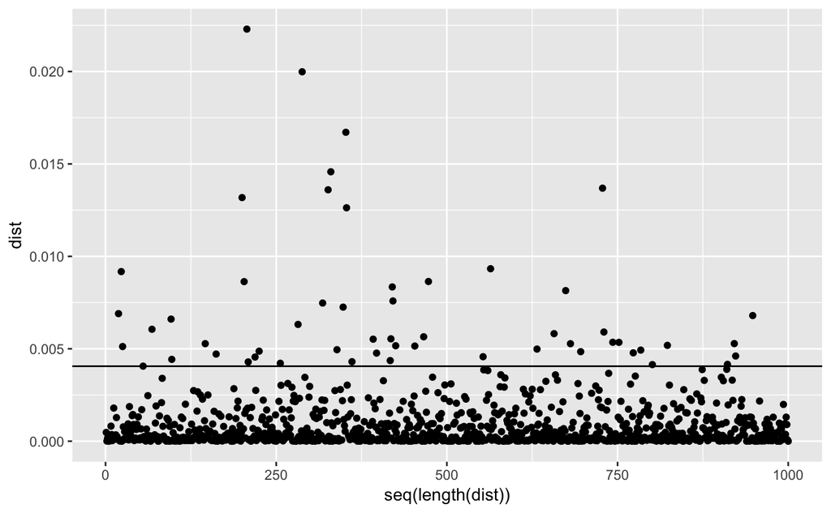

```r
ggplot(data.frame(dist=distance)) + geom_point(aes(x=seq(length(dist)), y=dist)) + geom_hline(yintercept = cutoff)
```

Measureing leverage

```r
leverages <- hatvalues(fit)
outlier <- which(leverages == max(leverages))
```

```r
data %>% slice(outlier)
```

| tenure | age | marital | address | income | ed | employ | retire | gender | longmon | wiremon | churn |
| --- | --- | --- | --- | --- | --- | --- | --- | --- | --- | --- | --- |
| 58 | 70 | Unmarried | 2 | 2.197225 | Some college | 24 | Yes | Female | 3.148453 | 35.15 | No |

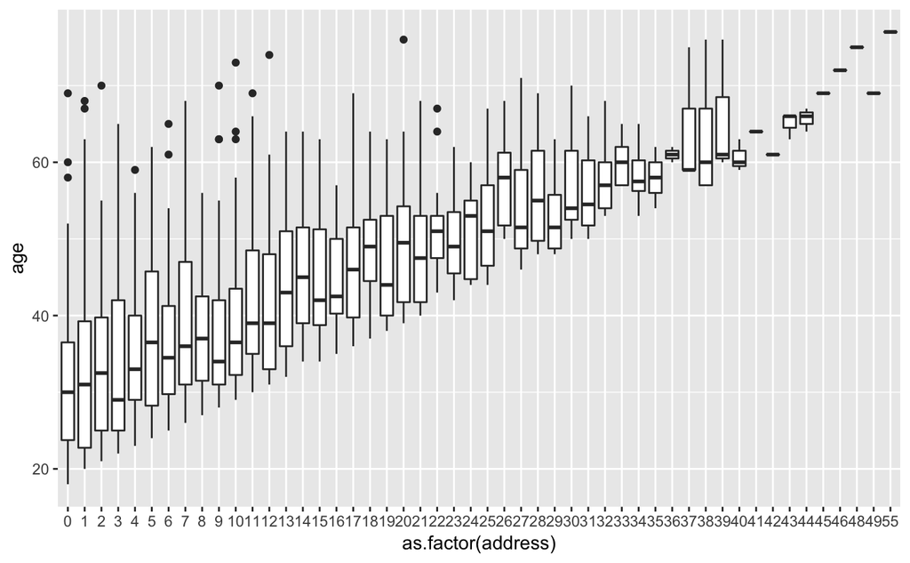

```r
ggplot(data) + geom_boxplot(aes(y=age, x=as.factor(address)))
```

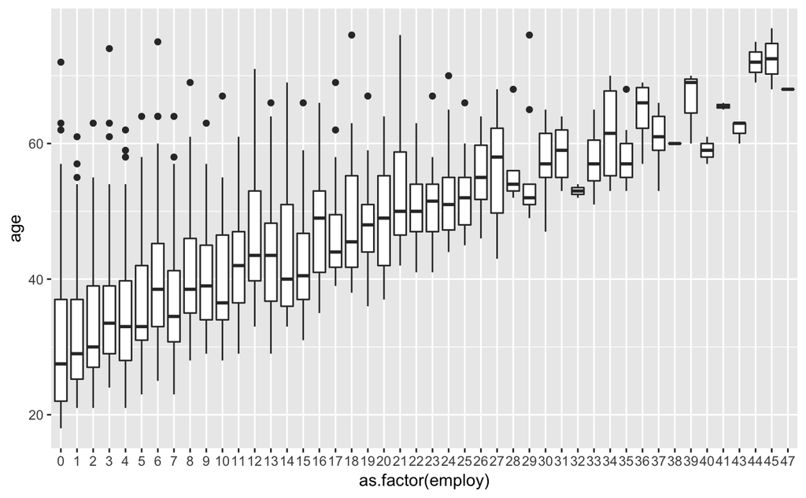

```r
ggplot(data) + geom_boxplot(aes(y=age, x=as.factor(employ)))
```

#### Item 8

```r
s <- slice(data, 5:10)
s$address = NULL
```

```r
s
```

| tenure | age | marital | income | ed | employ | retire | gender | longmon | wiremon | churn |
| --- | --- | --- | --- | --- | --- | --- | --- | --- | --- | --- |
| 23 | 30 | Married | 3.401197 | Did not complete high school | 2 | No | Male | 1.840550 | 0.0 | No |
| 41 | 39 | Unmarried | 4.356709 | High school degree | 16 | No | Female | 2.468100 | 0.0 | No |
| 45 | 22 | Married | 2.944439 | High school degree | 4 | No | Female | 2.388763 | 0.0 | Yes |
| 38 | 35 | Unmarried | 4.330733 | High school degree | 10 | No | Male | 1.800058 | 64.9 | No |
| 45 | 59 | Married | 5.111988 | College degree | 31 | No | Male | 2.277267 | 0.0 | No |
| 68 | 41 | Married | 4.276666 | Did not complete high school | 22 | No | Male | 3.184284 | 0.0 | No |

We will implement imputation for address value with following strategies:

1. the most popular along the dataset. Just take the median value for the data set and calculate the error of the imputation

```r
s <- slice(data, 5:10)
gt <- s$address
s$address = NULL
m <-  median(data$address)
```

Error

```r
print(m)
```

```
[1] 9
```

```r
s$address = m
error <-  sum((gt - m)^2)
```

Error

```r
print(error)
```

```
[1] 277
```

2. Regression imputation. This is very baseline regression imputation that can be improved with improving the regression model. As we can see the error of the imputation is less than using just the median value.

```r
s <- slice(data, 5:10)
gt <- s$address
s$address = NULL
im = lm(address ~ ., data=data)
predicted = round(predict(im, s))
error = sum((gt - predicted)^2)
```

```r
print(error)
```

```
[1] 211
```

If the value retires is missing we could try use classification model to impute the data. Also, it’s possible to do clustering and assign values using clustering algorithms. If retire is missing from a small amount of the data - probably we could just drop the rows with missing data.

#### Item 9

High p-value indicates there’s not strong evidence that variance is significantly different for different values of address. The same we can see on the plots. If there is different variance for each group - FGLS can help to adjust predictions to the different variances. For example if we have exponential varieance we could estimate weigths that later will be applied to the coefficients and predictions of the model, adjusting them to the different variances. There are different models that can work with heteroscedasticity, their selection depends on how much information do you have. For example, do you know the real variance formula or it should be estimated(weighted gls/white estimator)

```r
add_count <- data %>% group_by(address) %>% count() %>% filter(n>1)
btdat <- data %>% filter(address %in% add_count$address)
model = lm(formula = longmon ~ tenure + age + marital + address + income +
    ed + retire + gender, data = btdat)
```

```r
bartlett.test(formula=model$residuals ~ btdat$address)
```

```
    Bartlett test of homogeneity of variances

data:  model$residuals by btdat$address
Bartlett's K-squared = 40.915, df = 42, p-value = 0.5185
```

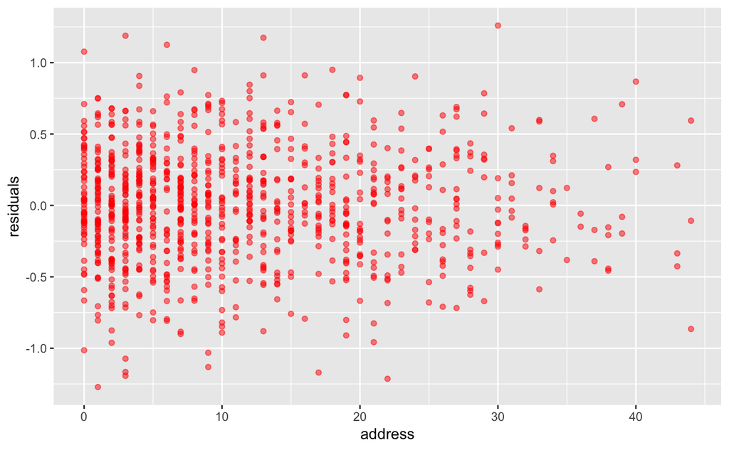

```r
ggplot(data.frame(residuals=model$residuals, address=btdat$address)) +
  geom_point(aes(x=address, y=residuals, group=address), color='red', alpha=0.5)
```

```r
ggplotRegression <- function (fit) {
require(ggplot2)
i = 5
ggplot(fit$model, aes_string(x = names(fit$model)[i], y = names(fit$model)[1])) +
  geom_point() +
  stat_smooth(method = "lm", col = "red") +
  labs(title = paste("Adj R2 = ",signif(summary(fit)$adj.r.squared, 5),
                     "Intercept =",signif(fit$coef[[1]],5 ),
                     " Slope =",signif(fit$coef[[i]], 5),
                     " P =",signif(summary(fit)$coef[i,4], 5)))
}
```

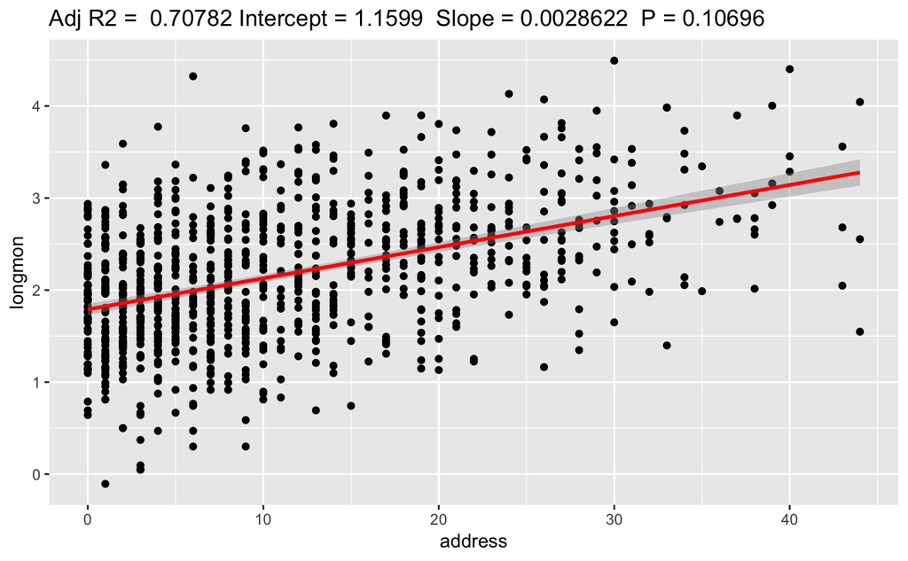

```r
ggplotRegression(model)
```